# PA1_template

Upzip of the file after the download of the file and Adding the file to the data.frame

```r
unzip("activity.zip")
activity1 <- read.csv("activity.csv")
```

Create a histogram of the aggregation for the Histogram of the total number of steps taken each day

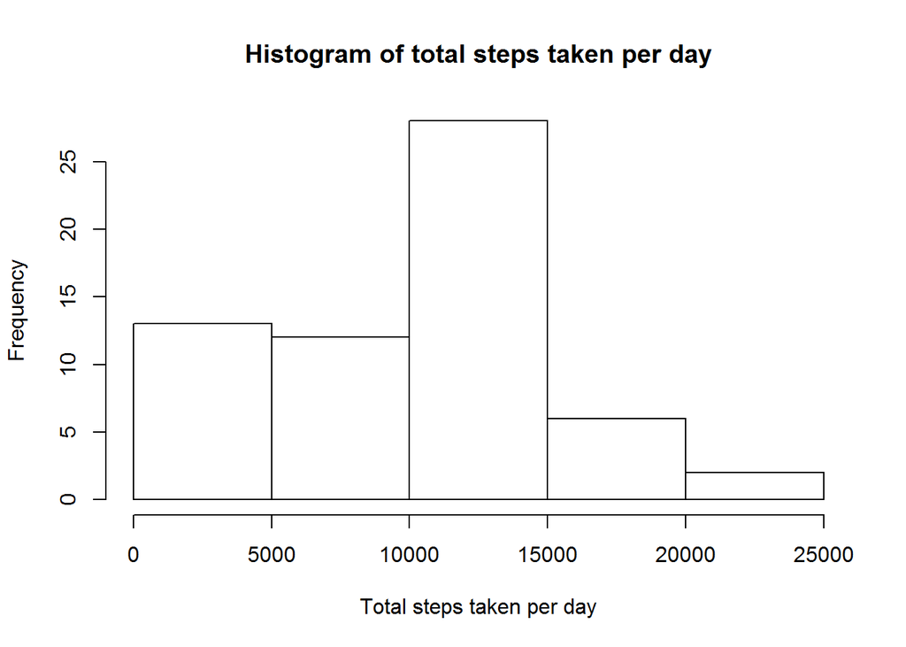

```r
hist((aggregate(steps ~ date,activity1,sum,na.action = NULL,na.rm = TRUE))$steps,main = "Histogram of total steps taken per day",xlab = "Total steps taken per day")
```

Calculating the total number of steps taken and then there mean and median

```r
mean((aggregate(steps ~ date,activity1,sum,na.action = NULL,na.rm = TRUE))$steps)
```

```
## [1] 9354.23
```

```r
median((aggregate(steps ~ date,activity1,sum,na.action = NULL,na.rm = TRUE))$steps)
```

```
## [1] 10395
```

Plots to create time series plot with the interval and average number of steps taken.

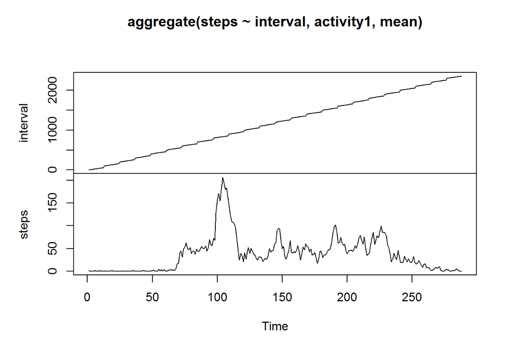

```r
plot.ts(aggregate(steps ~ interval,activity1,mean))
```